TRexSelector R package guide

# T-Rex SPCA: sparse principal components under FDR control

# Sparse loadings with a guarantee

Principal component analysis (PCA) finds the directions of largest variance, and every variable contributes to every loading vector. Sparse PCA asks for loadings with few non-zero entries, so that a component can be read as a small set of variables. The T-Rex sparse PCA (T-Rex SPCA) [1] decides which variables enter a loading vector with the T-Rex selector. For each of the $M$ components, ordinary PCA gives the component as a response, the T-Rex selector selects the variables for it at the target false discovery rate (FDR), and a sparse loading vector is assembled from the selected set. The selected set of every component is FDR-controlled.

# Data with two sparse factors

Two latent factors, the first loading on variables 1 to 10 and the second on variables 31 to 40, plus noise.

```r
set.seed(77)
n <- 200
p <- 60
Z <- matrix(rnorm(n * 2), n, 2)
V <- matrix(0, p, 2)
V[1:10, 1] <- 1 / sqrt(10)
V[31:40, 2] <- 1 / sqrt(10)
X <- 6 * Z[, 1] %*% t(V[, 1]) + 3 * Z[, 2] %*% t(V[, 2]) + matrix(rnorm(n * p), n, p)
```

# Running the selector

`TRexSPCASelector$new(X, M, tFDR, control, seed, verbose)` extracts `M` components. The elastic-net penalty of the inner selector is chosen by cross-validation by default. `X` is centered in place during `select()` and restored on return.

```r
spca <- TRexSPCASelector$new(X, M = 2, tFDR = 0.1, seed = 9, verbose = FALSE,
                             control = trex_spca_control(K = 10))
spca$select()
spca$active_sets
```

```
#> [[1]]
#>  [1]  1  2  3  4  5  6  7  8  9 10
#>
#> [[2]]
#>  [1] 31 32 33 34 35 36 37 38 39 40
```

The results are the scores `Z` ($n \times M$), the sparse loadings `V` ($p \times M$), the selected sets, and the explained variance.

```r
dim(spca$Z)
```

```
#> [1] 200   2
```

```r
dim(spca$V)
```

```
#> [1] 60  2
```

```r
round(spca$adjusted_ev, 3)
```

```
#> [1] 38.578  9.919
```

```r
round(spca$cumulative_ev, 3)
```

```
#> [1] 0.364 0.458
```

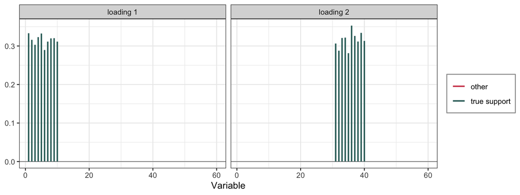

The two sparse loading vectors. The true supports are variables 1 to 10 and 31 to 40.

```r
library(ggplot2)
loadings <- data.frame(variable = rep(seq_len(p), 2), loading = c(spca$V[, 1], spca$V[, 2]),
                       component = rep(c("loading 1", "loading 2"), each = p))
on_support <- (loadings$component == "loading 1" & loadings$variable %in% 1:10) |
  (loadings$component == "loading 2" & loadings$variable %in% 31:40)
loadings$kind <- ifelse(on_support, "true support", "other")
ggplot(loadings, aes(variable, loading, colour = kind)) +
  geom_hline(yintercept = 0, linewidth = 0.3, colour = "grey40") +
  geom_segment(aes(xend = variable, yend = 0), linewidth = 0.8) +
  facet_wrap(~ component) +
  scale_colour_manual(values = c("true support" = "#336C68", "other" = "#D1495B")) +
  labs(x = "Variable", y = NULL, colour = NULL) +
  theme_bw(base_size = 11) +
  theme(legend.position = "right",
        legend.background = element_rect(fill = "white", colour = "grey60"))
```

# The control

`trex_spca_control()` sets the inner machinery.

- `mode`: `"ActiveSet"` (default) assembles the loading by a ridge regression of the component on the selected variables with penalty `lambda2_ridge_loadings`, `"Thresholded"` keeps the top $|A|$ ordinary loadings and normalizes them.
- `lambda_2` and `lambda2_method`: the elastic-net penalty of the inner group selector, fixed or chosen by ridge cross-validation (`"CV_1SE_CCD"` by default when `lambda_2 < 0`). A value of 0 is the degenerate lasso case and gives a warning.
- `en_solver`: `"TENET_AUG"` (default) or `"TENET"`, two forms of the same elastic net.
- `K` and `max_dummy_multiplier`: the random experiments and the dummy cap of the inner selector.

T-Rex SPCA is defined on the elastic net, and `gvs_type = "IEN"` is rejected.

```r
thr <- TRexSPCASelector$new(X, M = 2, tFDR = 0.1, seed = 9, verbose = FALSE,
                            control = trex_spca_control(mode = "Thresholded", K = 10))
thr$select()
thr$active_sets
```

```
#> [[1]]
#>  [1]  1  2  3  4  5  6  7  8  9 10
#>
#> [[2]]
#>  [1] 31 32 33 34 35 36 37 38 39 40
```

```r
round(thr$cumulative_ev, 3)
```

```
#> [1] 0.365 0.459
```

# Memory-mapped data

`X` may be a memory-mapped matrix opened in `"readwrite"` mode (see the memory-mapping page). It is centered in the file during `select()` and restored.

# Examples

The [TRexSelector_Examples](https://github.com/trexselector/TRexSelector_Examples/tree/main) repository holds runnable demos and Monte Carlo studies of T-Rex SPCA, with their results and a README per demo, in [R](https://github.com/trexselector/TRexSelector_Examples/tree/main/R/trex_selector_methods/ad/trex_spca), [Python](https://github.com/trexselector/TRexSelector_Examples/tree/main/Python/trex_selector_methods/ad/trex_spca) and [C++](https://github.com/trexselector/TRexSelector_Examples/tree/main/cpp/trex_selector_methods/ad/trex_spca).

# Bibliography

[1]

J. Machkour, A. Breloy, M. Muma, D. P. Palomar, and F. Pascal, “Sparse PCA with false discovery rate controlled variable selection,” in *Proc. IEEE 49th int. Conf. Acoust., speech, signal process. (ICASSP)*, 2024, pp. 9716–9720. doi: 10.1109/ICASSP48485.2024.10448237.